# isoviz

```r
library(isoviz)
library(dplyr)
library(readr)
library(ggplot2)
```

# Introduction

Our package aims to help quantify and visualize the transcript isoforms that are present in your samples.

# Exemplary workflow

We start off by loading all our exon and intron coordinates. By default, this will use ‘gencode.v41.basic annotation’ data. You can also input your own psl file (gtf file as well in the future).

```r
file_path <- system.file("data", "gencode.v41.basic.annotation.psl", package="isoviz")
gene_trans <- system.file("data", "gencode_v41_gene_transcript_convert.txt", package="isoviz")

all_coordinates <- isoviz_coords(file_path, gene_trans, input_type="psl") #use default genome .psl file
```

```
#> [1] "116566 transcripts with at least one intron!"
#> [1] "116566 transcripts with at least one intron!"
#>
```

```r
# Let's look at the exon coordinates
exon_coords <- all_coordinates[[1]]
print(head(exon_coords))
```

```
#>     chr start   end          trans_id           gene_id strand blocksizes
#> 1: chr1 11868 14409 ENST00000456328.2 ENSG00000223972.5      +        359
#> 2: chr1 11868 14409 ENST00000456328.2 ENSG00000223972.5      +        109
#> 3: chr1 11868 14409 ENST00000456328.2 ENSG00000223972.5      +       1189
#> 4: chr1 12009 13670 ENST00000450305.2 ENSG00000223972.5      +         48
#> 5: chr1 12009 13670 ENST00000450305.2 ENSG00000223972.5      +         49
#> 6: chr1 12009 13670 ENST00000450305.2 ENSG00000223972.5      +         85
#>    blockstarts transcript_length blockends gene_name transcript_name
#> 1:       11868              2541     12227   DDX11L1     DDX11L1-202
#> 2:       12612              2541     12721   DDX11L1     DDX11L1-202
#> 3:       13220              2541     14409   DDX11L1     DDX11L1-202
#> 4:       12009              1661     12057   DDX11L1     DDX11L1-201
#> 5:       12178              1661     12227   DDX11L1     DDX11L1-201
#> 6:       12612              1661     12697   DDX11L1     DDX11L1-201
#>                             gene_type                    transcript_type
#> 1: transcribed_unprocessed_pseudogene               processed_transcript
#> 2: transcribed_unprocessed_pseudogene               processed_transcript
#> 3: transcribed_unprocessed_pseudogene               processed_transcript
#> 4: transcribed_unprocessed_pseudogene transcribed_unprocessed_pseudogene
#> 5: transcribed_unprocessed_pseudogene transcribed_unprocessed_pseudogene
#> 6: transcribed_unprocessed_pseudogene transcribed_unprocessed_pseudogene
```

```r
# Let's look at the intron coordinates
intron_coords <- all_coordinates[[2]]
print(head(intron_coords))
```

```
#>      chr intron_starts intron_ends            gene_id           trans_id strand
#> 1:  chr7     127588565   127589083 ENSG00000004059.11 ENST00000000233.10      +
#> 2:  chr7     127589163   127589485 ENSG00000004059.11 ENST00000000233.10      +
#> 3:  chr7     127589594   127590066 ENSG00000004059.11 ENST00000000233.10      +
#> 4:  chr7     127590137   127590963 ENSG00000004059.11 ENST00000000233.10      +
#> 5:  chr7     127591088   127591213 ENSG00000004059.11 ENST00000000233.10      +
#> 6: chr12       8941940     8942416  ENSG00000003056.8  ENST00000000412.8      -
#>    gene_name transcript_name      gene_type transcript_type
#> 1:      ARF5        ARF5-201 protein_coding  protein_coding
#> 2:      ARF5        ARF5-201 protein_coding  protein_coding
#> 3:      ARF5        ARF5-201 protein_coding  protein_coding
#> 4:      ARF5        ARF5-201 protein_coding  protein_coding
#> 5:      ARF5        ARF5-201 protein_coding  protein_coding
#> 6:      M6PR        M6PR-201 protein_coding  protein_coding
```

Let’s make a basic plot of the isoforms for the gene RBFOX2. We will also look at how to rescale the coordinates in case the gene has very long introns.

```r
rbfox2_exons <- filter(exon_coords, gene_name == "RBFOX2")
rbfox2_introns <- filter(intron_coords, gene_name == "RBFOX2")

# let's rescale the intron coordinates but keep the relative exon alignments
# this step will return an updated dataframe of exon coordinates that we can use
# with our plotting function

rescaled_coords = isoviz_rescale_introns(rbfox2_introns, rbfox2_exons, width_rescale=10)
```

```
#> [1] "-"
#> [1] "RBFOX2-209"
#> [1] "getting ref coordinates"
#> [1] "RBFOX2-201"
#> [1] "RBFOX2-202"
#> [1] "RBFOX2-203"
#> [1] "RBFOX2-205"
#> [1] "RBFOX2-207"
#> [1] "RBFOX2-208"
#> [1] "RBFOX2-210"
#> [1] "RBFOX2-215"
#> [1] "RBFOX2-216"
#> [1] "RBFOX2-220"
#> [1] 1
#> [1] 2
#> [1] 3
#> [1] 4
#> [1] 5
#> [1] 6
#> [1] 7
#> [1] 8
#> [1] 9
#> [1] 10
```

```r
head(rescaled_coords)
```

```
#>    transcript_name   chr    start      end strand blocksizes new_e_start
#> 1:      RBFOX2-201 chr22 35810004 35809779      -        225     22454.6
#> 2:      RBFOX2-201 chr22 35781743 35781599      -        144     25486.0
#> 3:      RBFOX2-201 chr22 35768349 35768256      -         93     27003.8
#> 4:      RBFOX2-201 chr22 35765483 35765422      -         61     27374.2
#> 5:      RBFOX2-201 chr22 35761468 35761414      -         54     27830.7
#> 6:      RBFOX2-201 chr22 35761294 35761201      -         93     27896.8
#>    new_e_end exon_num min_start max_end transcript_length
#> 1:   22679.6        2   19219.8 30314.8             11095
#> 2:   25630.0        3   19219.8 30314.8             11095
#> 3:   27096.8        4   19219.8 30314.8             11095
#> 4:   27435.2        5   19219.8 30314.8             11095
#> 5:   27884.7        6   19219.8 30314.8             11095
#> 6:   27989.8        7   19219.8 30314.8             11095
```

We will first need to load our leafcutter junctions that we obtained by running Regtools extract junctions on our BAM files. You can use one of our preloaded cell types or first run this on your own BAM file and then use as input for this function. We will look at junctions in hESC data. We will first need to run ‘minicutter’ to cluster the junction coordinates and obtain intron cluster events.

```
#> [1] "Printing summary of intron-cluster sizes = how many junctions across in clusters"
```

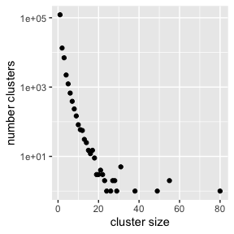

```
#> [1] "Printing summary of intron-cluster sizes = how many junctions across in clusters"
```

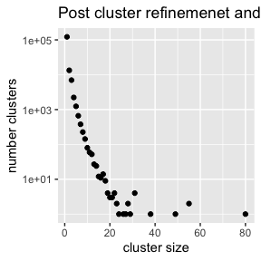

```r
# load junctions for cell type of interest or input your own
junctions <- system.file("data", "hESC-MKNK2-G1_v41_basic.junc", package="isoviz")

# run minicutter to get clusters
intron_clusts <- isoviz_minicutter(juncs_file = junctions)
```

```r
print(head(intron_clusts))
```

```
#> # A tibble: 6 × 10
#>   chrom strand  start    end name        readcount idx_start idx_end cluster_idx
#>   <chr> <chr>   <dbl>  <dbl> <chr>           <int>     <int>   <int>       <dbl>
#> 1 chr1  +       16717 187231 JUNC000000…         6         1       5           1
#> 2 chr1  +       23782 194308 JUNC000000…         3         2       6           2
#> 3 chr1  -       90050  90287 JUNC000000…         1     17151   17152        7295
#> 4 chr1  -      136463 136562 JUNC000000…         8     17153   17155        7296
#> 5 chr1  -      136512 136904 JUNC000000…         2     17154   17159        7297
#> 6 chr1  -      136708 136904 JUNC000000…         1     17156   17159        7297
#> # ℹ 1 more variable: usage_ratio <dbl>
```

Let’s take a look at how junctions were grouped into intron clusters. Note, some of these clusters will only contain one junction (singleton). You will have the option to change this when running isoviz_minicutter.

```r
# For now we will use the expanded intron dataset with additional annotations by Megan
# We will need an additional function to add these annotations
intron_annotations <- system.file("data", "gencode_intron_all_data.rda", package="isoviz")
load(intron_annotations)
print(head(gencode_intron_all_data))
```

```
#> # A tibble: 6 × 10
#>   chr   junc_start junc_end gene_id           strand junc_id gene_name gene_type
#>   <chr>      <dbl>    <dbl> <chr>             <chr>  <chr>   <chr>     <chr>
#> 1 chr1       30039    30564 ENSG00000243485.5 +      junc1   MIR1302-… lncRNA
#> 2 chr1       30667    30976 ENSG00000243485.5 +      junc2   MIR1302-… lncRNA
#> 3 chr1       35174    35277 ENSG00000237613.2 -      junc3   FAM138A   lncRNA
#> 4 chr1       35481    35721 ENSG00000237613.2 -      junc4   FAM138A   lncRNA
#> 5 chr1       65433    65520 ENSG00000186092.7 +      junc5   OR4F5     protein_…
#> 6 chr1       65573    69037 ENSG00000186092.7 +      junc6   OR4F5     protein_…
#> # ℹ 2 more variables: junction_category <chr>, transcript_isoforms <chr>
```

Let’s continue working on RBFOX2. Now we have to map the observed junctions with their corresponding exons and transcript isoforms. To do this, we will use the `isoviz_map_junctions` function. Make sure to check strand of gene!

```r
mapped_junctions = isoviz_map_junctions(cell_type = "hESC", rbfox2_introns, intron_clusts, gencode_intron_all_data)
print(head(mapped_junctions))
```

```
#> # A tibble: 6 × 25
#>   chr   intron_starts intron_ends strand name      junc.counts idx_start idx_end
#>   <chr>         <dbl>       <dbl> <chr>  <chr>           <dbl>     <int>   <int>
#> 1 chr22      35744249    35745923 -      JUNC0019…          48    220296  220297
#> 2 chr22      35744249    35745923 -      JUNC0019…          48    220296  220297
#> 3 chr22      35744249    35745923 -      JUNC0019…          48    220296  220297
#> 4 chr22      35744249    35745923 -      JUNC0019…          48    220296  220297
#> 5 chr22      35744249    35745923 -      JUNC0019…          48    220296  220297
#> 6 chr22      35744249    35745923 -      JUNC0019…          48    220296  220297
#> # ℹ 17 more variables: cluster_idx <dbl>, usage_ratio <dbl>,
#> #   cluster.counts <dbl>, gene_id <chr>, trans_id <chr>, gene_name <chr>,
#> #   transcript_name <chr>, gene_type <chr>, transcript_type <chr>,
#> #   junction_category <chr>, junc_id <chr>, transcript_isoforms <chr>,
#> #   junc.per.cluster <dbl>, junc.usage <dbl>, cell_line <chr>,
#> #   transcript_targetable <chr>, isoform_expressed <chr>
```

Now we are ready to make a plot!

[output not shown]

[figure not shown]

```r
isoviz_plot_juncs_to_iso(mapped_junctions, rbfox2_exons,
                                    cell_type = "hESC",
                                    junction_usage = 5, #min junc usage to be included
                                    include_all_juncs = FALSE,
                                    include_specific_junctions = c("JUNC00193787", "JUNC00193785", "JUNC00193786", "unk.7"))
```